# Data Handling: Import, Cleaning and Visualisation

Lecture 11:  
Wrap up

Dr. Aurélien Sallin

2024-12-19

## Plan for today

1. Recap
2. Example of a Shiny app
3. Wrap up
4. Exam Info
5. Suggested Improvements
6. Concluding remarks
7. Q&A

# Recap: Data Visualization and Text Data

## Data visualization

Two ways: display data through *tables* or *graphs*.

Depends on the purpose.

## `ggplot2` basics

Using `ggplot2` to generate a basic plot in R is quite simple. Three key points:

1. The data must be stored in a `data.frame`/`tibble` (in tidy format!).
2. The starting point of a plot is always the function `ggplot()`.
3. The first line of plot code declares the data and the ‘aesthetics’ (e.g., which variables are mapped to the x-/y-axes):

```r
ggplot(data = my_dataframe, aes(x= xvar, y= yvar))
```

## `ggplot2`: building plots layer by layer

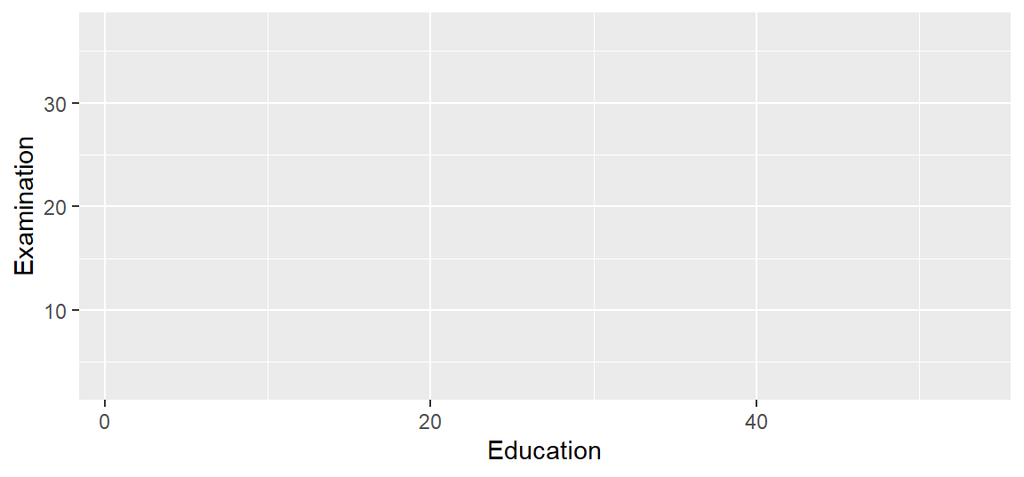

```r
ggplot(data = swiss, aes(x = Education, y = Examination))
```

## `ggplot2`: building plots layer by layer

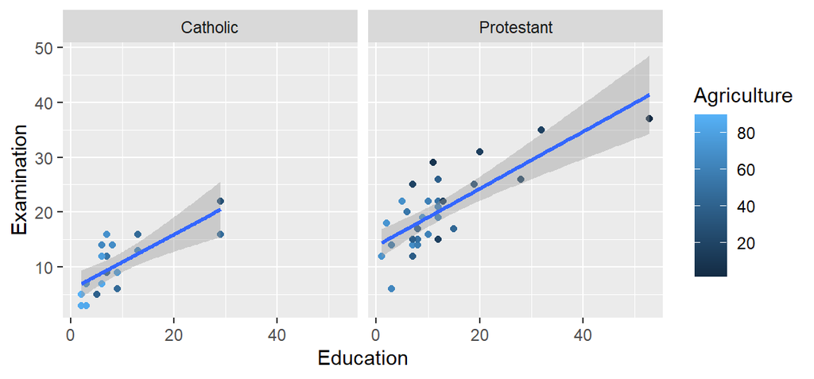

```r
ggplot(data = swiss, aes(x = Education, y = Examination)) +
  geom_point(aes(color = Agriculture)) +
  geom_smooth(method = 'lm') +
  facet_wrap(~Religion)
```

## Tufte’s principles of data visualization

#### Minimize the **Lie Factor**

$\frac{\text{size of effect shown in graphic}}{\text{size of effect in data}}$

#### Maximize the **Data-ink Ratio**

$\frac{\text{ink used for data points}}{\text{total ink used to print the graphic}}$

#### Maximize the **Data density**

$\frac{\text{number of entries in data matrix}}{\text{area of data graphic}}$

## Minimize the **Lie Factor**

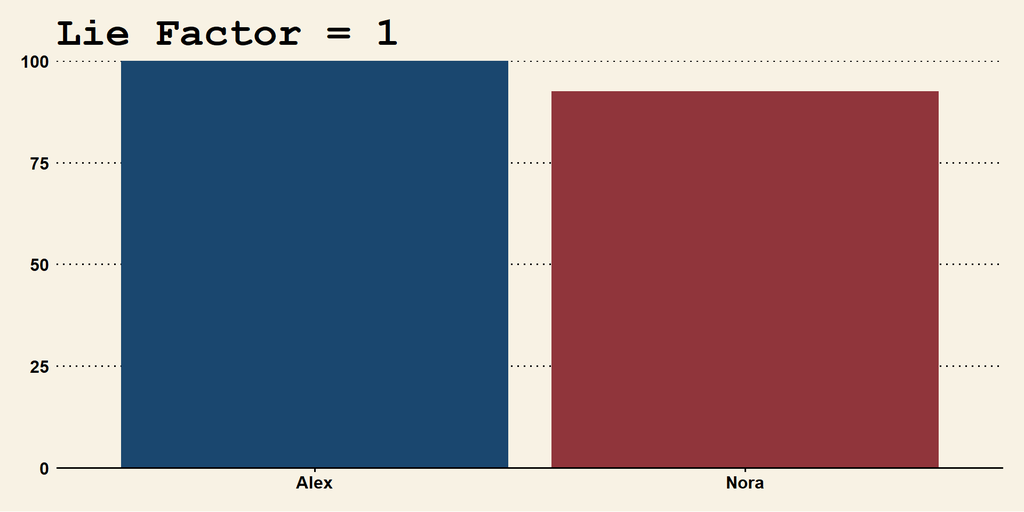

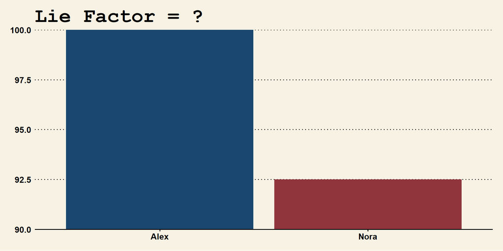

**Lie Factor**

The Lie Factor is 3.7 (((10/2.5))/((100/92.5)))

## Maximize the **Data-ink Ratio**

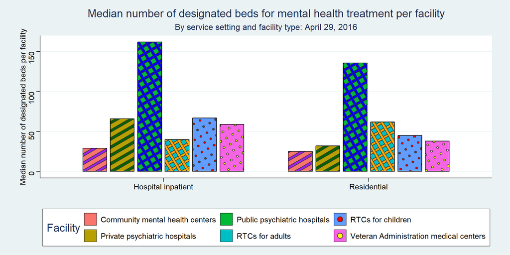

**Show code for the graphs**

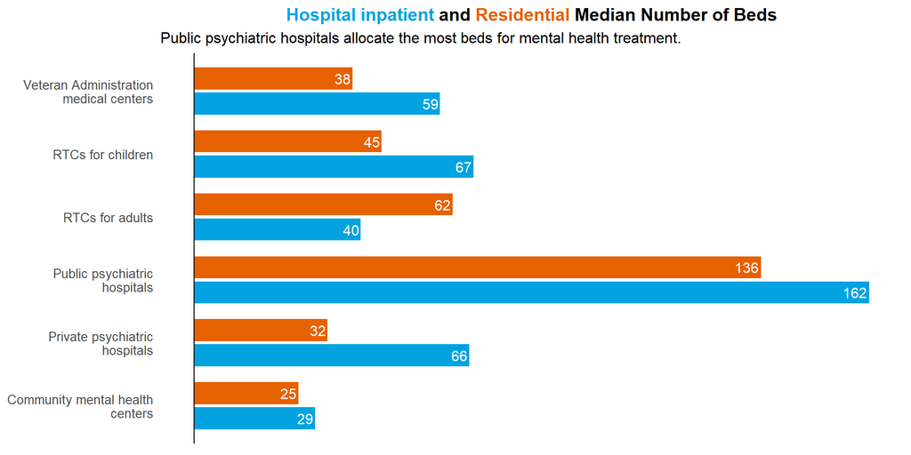

```r
ggplot(data, aes(x = Setting, y = Beds, pattern = Facility, fill = Facility, group = Facility)) +
  geom_col_pattern(
    aes(pattern = Facility, fill = Facility, pattern_fill = Facility),
    colour = 'black',
        width = 0.7,
    position = position_dodge(width = 0.8),
    pattern_density          = 0.35) +
    scale_pattern_fill_manual(
      values = c("Public psychiatric hospitals"='blue',
                 "RTCs for children"='red',
                 "Veteran Administration medical centers"='yellow',
                 "Private psychiatric hospitals"='darkgreen',
                 "RTCs for adults" = 'orange',
                 "Community mental health centers" = 'purple')) +
  labs(title = "Median number of designated beds for mental health treatment per facility",
       subtitle = "By service setting and facility type: April 29, 2016",
       x = "",
       y = "Median number of designated beds per facility") +
  theme_stata(base_size = 12) +
  theme(legend.position = "bottom",
        axis.text.x = element_text(angle = 0, hjust = 0.5))
```

**Show code for the graphs**

```r
data$Facility <- str_wrap(data$Facility, width = 25)

ggplot(data, aes(x = Beds, y = Facility, fill = Setting)) +
  geom_col(position = position_dodge(width = 0.8), width = 0.7) +
   geom_text(aes(label = Beds),
            position = position_dodge(width = 0.8),  # Align with bars
            hjust = 1.1,  # Align left/right
            color = "white", size = 4) +  # Text color and sizesst color and size of the text
  scale_fill_manual(values = c("Hospital inpatient" = "#00A3E0",  # Cyan for hospital inpatient
                               "Residential" = "#E66100")) +     # Dark blue for residential
  labs(
    title = "<span style='color:#00A3E0;'>Hospital inpatient</span> and <span style='color:#E66100;'>Residential</span> Median Number of Beds",
    subtitle = "Public psychiatric hospitals allocate the most beds for mental health treatment.",
    x = NULL,
    y = NULL
  ) +
  theme_minimal(base_size = 12) +
  theme(
    axis.text.x = element_blank(),  # Remove x-axis labels
    axis.ticks.x = element_blank(),
    axis.text.y = element_text(size = 10),
    legend.position = "none",
    plot.title = element_markdown(hjust = 0.5, size = 14, face = "bold"),  # Title with colored text
    panel.grid = element_blank()  # Remove grid lines
  ) +
  geom_vline(xintercept = 0, color = "black", linetype = "solid", size = 0.5)
```

## Maximize data density

[figure not shown]

Source: [data-viz-workshop-2021](https://badriadhikari.github.io/data-viz-workshop-2021/Tufte/Chapter_8/)

#### 4 data points: 0.39, 0.56, 0.3, 2000 😱

## Eight Steps in Text Analysis

Focus on steps 1-4 in this course.

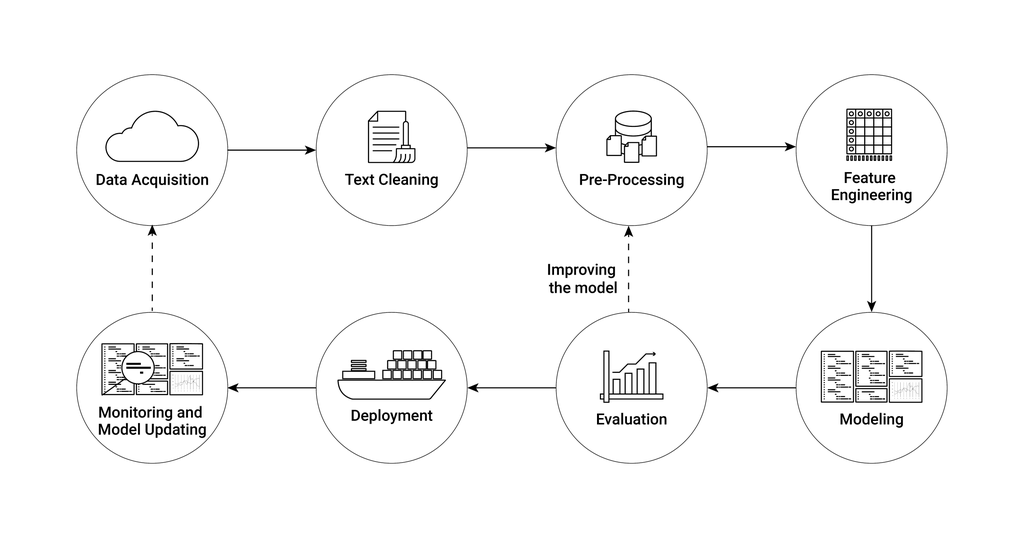

- In `R`, we use `quanteda`: Comprehensive package for preprocessing, visualization, and statistical analysis of text data.

## Data aqcuisition: From Raw Text to Corpus

The base, raw material, of quantitative text analysis is a **corpus**. A corpus is, in NLP, *a collection of authentic text organized into datasets*.

- In `quanteda`: A data frame with a character vector for documents and additional metadata columns.

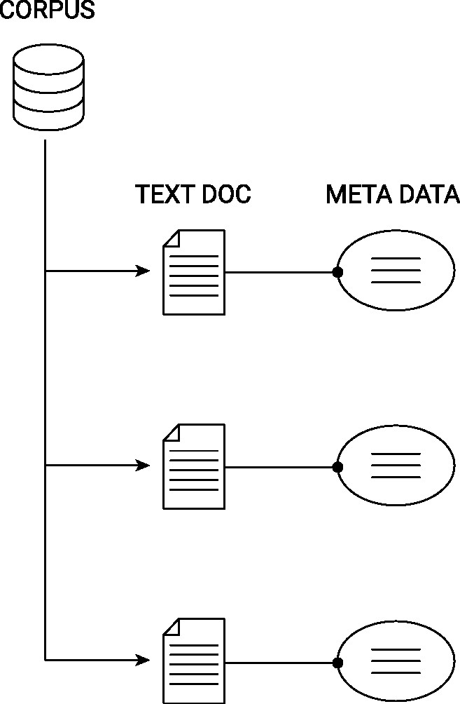

```r
print(corp)
```

```
Corpus consisting of 5 documents and 3 docvars.
text1 :
"Fellow-Citizens of the Senate and of the House of Representa..."

text2 :
"Fellow citizens, I am again called upon by the voice of my c..."

text3 :
"When it was first perceived, in early times, that no middle ..."

text4 :
"Friends and Fellow Citizens: Called upon to undertake the du..."

text5 :
"Proceeding, fellow citizens, to that qualification which the..."
```

## Cleaning/pre-processing: from corpus to tokens

**Tokens**: Building blocks of text analysis, smallest unit of text.

- The tokenization process allows to convert raw text into numerical representations by mapping each token to an integer ID.
  - e.g., words: “The cat sat” becomes a vector of three characters [“The”, “cat”, “sat”]
- Remove “noise” such as punctuation and stopwords.
- Create N-grams (e.g., bigrams like “not friendly”).

```
 [1] "Fellow-Citizens" "Senate"          "House"           "Representatives" "Among"
 [6] "vicissitudes"    "incident"        "life"            "event"           "filled"
[11] "greater"         "anxieties"       "notification"    "transmitted"     "order"
[16] "received"        "14th"            "day"             "present"         "month"
```

## Feature engineering: From Tokens to Document-Term Matrix

- **DTM**: Document-Term Matrix with rows = documents and columns = tokens.
- Contains count frequencies or indicators.
- Sparse (most entries are zero). The dimensions need to be reduced.

```r
dfmat <- dfm(toks)
dfmat <- dfm_trim(dfmat, min_termfreq = 2) # remove tokens that appear less than 1 times
print(dfmat)
```

```
Document-feature matrix of: 5 documents, 602 features (56.18% sparse) and 3 docvars.
       features
docs    fellow-citizens senate house representatives among life event greater order day
  text1               1      1     2               2     1    1     2       1     2   2
  text2               0      0     0               0     0    0     0       0     0   0
  text3               3      1     0               2     4    2     0       0     4   1
  text4               2      0     0               0     1    1     0       1     1   1
  text5               0      0     0               0     7    2     0       0     3   1
[ reached max_nfeat ... 592 more features ]
```

## Analyzing DTMs

Very basic statistics about documents are the **top features** of each document, the frequency of expressions in the corpus.

The frequency of tokens can be represented in a text plot.

```r
library(quanteda.textplots)
quanteda.textplots::textplot_wordcloud(dfmat, max_words = 100)
```

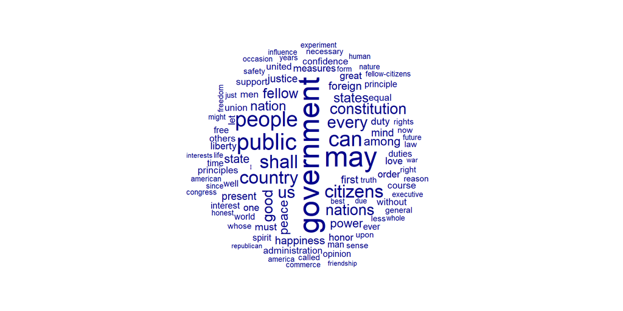

# Today

## Shiny app

- **Shiny** is an R package that makes it easy to build interactive web apps straight from R.
- Example with Data from the European Quality of Government Index (EQI).
- This index focuses on both perceptions and experiences with public sector corruption.
- Data: **EQI-CATI Country Level 2010-2024** (only phone interviews).
- Source: [QoG Institute](https://www.gu.se/en/quality-government/qog-data/data-downloads/european-quality-of-government-index)

## Data: EQI-CATI Country Level 2010-2024

```r
eqi <- read_csv("C:/Users/aurel/OneDrive/Documents/DataHandling/datahandling-lecture/materials/code_examples/qog_eqicati_long_24.csv") |>
  select(cname, year, Ed_qual, Hel_qual, Law_qual, Helimpart1, Hel_ask)

head(eqi)
```

```
# A tibble: 6 × 7
  cname    year Ed_qual Hel_qual Law_qual Helimpart1  Hel_ask
  <chr>   <dbl>   <dbl>    <dbl>    <dbl>      <dbl>    <dbl>
1 Austria  2010    6.24     6.81     6.64       4.27 NA
2 Austria  2013    6.51     6.80     6.53       5.07 NA
3 Austria  2017    6.68     7.27     7.22       5.72  0.0138
4 Austria  2021    7.19     7.67     7.42       4.85  0.00970
5 Austria  2024    6.90     6.92     7.16       5.47  0.0176
6 Belgium  2010    6.97     7.71     6.86       4.88 NA
```

# Wrap up

## At the end of the course, you will be able to…

- **Understand the tools you need when working with data**
- **Work independently with data**
- **Ask the right questions to a dataset**
- **Learn to communicate about data**

## My commitment to these goals and to your learning process

- **Transferrable skills**
- **Hands-on approach**
- **Emphasis on real-world relevance**  
  (caveat: this course is mandatory for Econ students, I have limited freedom in the syllabus)
- **As much fun as possible (as coding can be fun…😎)**

## Wrap up: Conceptual part

- Understand the very basics of how computers process data.
  - Binary code.
  - Representation of binary code as text (encodings/standards!).
  - Text files to store data: special characters (comma, semicolon, etc.) define the structure (following a standard!)
    - CSV: two-dimensional/table-like structure
    - JSON/XML: hierarchical data (high-dimensional)
  - Data in text file: how is data structured when stored on the hard disk (mass storage device).
  - Data structures in R (objects): How data is structured/represented when loaded into RAM (via a ‘parser’)

## Wrap up: Applied part: import, cleaning, analysis/visualisation.

- Get from the data source to the final data product:
  - `tidyverse`: tools to help you with every part of the data pipeline.
- Import data into R. What to do if the parsing fails?
- Clean/prepare data in R. Aim: tidy data set (rows:observations, columns:variables).
- Filter, select, mutate, summarise.
- Compute basic summary statistics using group_by and summarise.
- Visualize raw data and basic statistics.

# Exam

## 📢 Decentral exam and LockDown browser

#### Exam for exchange students

- 19.12.2024 at 16:15 in room 01-207.
- **BYO + cord🔌 + 🖱️**

#### Lockdown browser

- Exam and LockDown Browser: check Sharepoint on StudentWeb and test on Canvas.  
  **Password**: DataHandling2023

## Code questions

- True/False questions, multiple-choice questions, and multiple-correct options. These are designed to test your understanding of the material.
- ❗Exactly same style and structure as quizzes and mock exam❗
- We do not invent wrong function parameters or misspell function names etc to mislead you!
- ‘Passive’ knowledge of key R syntax and most important functions of core lecture contents are important!
- Work step-by-step through the code example. What happens in each parenthesis, on each line?
- From the inner part to the outer part, from top to bottom.
- Use pencil/paper to keep track of values, data structures (how does a data-frame look like?), classes.
- Importantly, if a code-example question refers to specific functions, you can always assume that the corresponding package is also loaded.

## Essay/open questions

- There will also be 3-4 essay-style questions aimed at evaluating your ability to apply your knowledge to new situations.
  - E.g., you might be asked to explain particular steps of the data analysis process in a given situation. You can use code, R concepts, or you can explain in plain English. The more precise the better.
- **You will not be required to write exact R code**, but you should be able to interpret and understand the code provided in the exam.
- I expect you to be familiar with all R commands and concepts covered in the lectures, exercises, in-class code, and additional practice exercises.
- The readings are not mandatory for the exam. The focus will be on the material discussed in class and during the exercises.

# Course Evaluation and Feedback

## Course Evaluation

### Very good overall evaluation. Thanks!!!😊😊

#### Positive feedback

- Quizzes, warm-up, exercises are helpful.
- In-class coding.
- Slides are nice.

#### Negative feedback

- Slides are too minimalistic.
- The pace was too fast.
- Objectives were not well-defined and clarified.

## Suggested Improvements

- **Learning Progress**
  - “*some lectures are a little slow (e.g. binary number systems) and others are really fast. it would be nice if the pace evened out a bit.*”
  - For some, the course is too fast, for some too slow (dsf program). Suggestions?
- **Course Objectives**
  - Clearer objectives and learning outcomes at the beginning of the course, clearer expectations for the exam. Suggestions?

## Suggested Improvements

- **More quizzes, more old exams, more mock exams** : 😵
- **Recordings** of the class: not an option for me.
- **html/pdf** issues in the slides. Sorry for this! 😞
- **Examination**: will be improved.

# Q&A

## Questions?

# Final Remarks

## Final Remarks

#### Let’s keep in touch!

- LinkedIn 📲
- Join the **`R` User Group in Zürich**!
  - Past events at Datahouse, SNB, Helsana, Swiss, etc.
  - Presentations from R-Users in the industry and in academia
  - Apéro + networking 🍕🍺
  - Next event: **23.01.2025, 18:30 - 21:00** at the Swiss Federal Institute for Forest, Snow, and Landscape Research on Geodata and Landscape Insights with R.
  - [Free Registration on Meetup](https://www.meetup.com/zurich-r-user-group/events/304647040/?notificationId=1450607390017687552&eventOrigin=notifications)

## Final Remarks

- I had a lot of fun 🙏
- All the best for your exams! 👍
- All the best for your studies and careers, *and finally, of course, …*

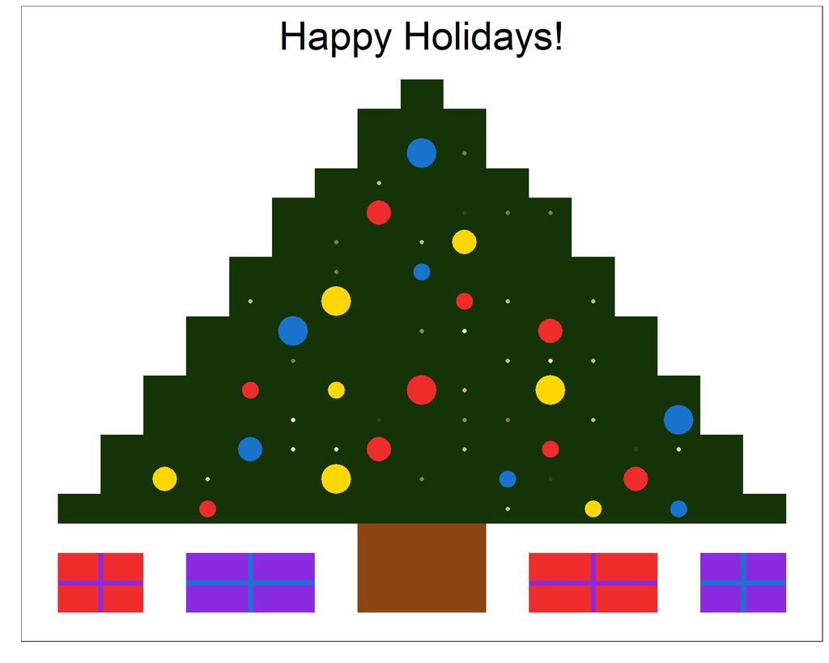

Made with `ggplot`. Source: [‘A very ggplot2 Christmas’](https://t-redactyl.io/blog/2016/12/a-very-ggplot2-christmas.html)